# HRMI Data Analysis

Clayton W. Caldwell

4 March 2022

Introduction:

Global development is a complicated subject, particularly because there is no one form of development. Any given nation could develop in a wide variety of ways as certain elements of development are given preference to others. One important concept is the effect of positive externalities in development that lead to development in one area having a positive impact on other aspects of development. For this reason, many aspects of global development influence one another and measuring a nation’s development patterns cannot be done by looking at a single developmental metric. It also makes measuring development in specific areas particularly complicated.

The Human Rights Measurement Initiative (HRMI) attempts to summarize the human rights performance of over 200 nations over a variety of economic, social, civil, and political rights. In addition to standard socioeconomic data such as GDP per capita and survival rate by age group, HRMI provides scores to a wide variety of different data based on current outcomes in that category versus what is economically feasible given the nation’s resources. These scores range from 0 to 100, with low scores indicating poor performance and high scores indicating high performance. It is important to note that some nations do not have consistent data across all variables and some do not have certain data whatsoever. The inconsistent data collection methods common in developing nations and the low incentive to publish human rights information found in nations committing human rights violations means that there are many unavailable data in the data set. Also important to note is that not all variables in the data set are relevant to all nations. For example, “Net Secondary School Enrolment” is relevant to high-income nations but not low-and-middle-income nations. More details regarding how the data is organized can be found in a PDF with the .zip file containing the current data set.

This project will use the current HRMI data set to explore how very different kinds of development may be related to one another in developing regions. Specifically, this project will explore the relationship between access to education and sanitation as described in the “ESR_LMY_IncomeAdjusted” subset of data. It is plausible that these to forms of development are correlated with one another because sanitation may serve as a barrier to education and education access could improve sanitation development. If the data are strongly correlated, then it may be possible to predict some of the missing data. The hypothesis statement is as follows:

##Among low-and-middle-income nations, there is a strong correlation between primary school enrollment and access to basic sanitation. A linear regression model can be created using these data that can provide rough estimates for missing data.

Data Analysis:

The project begins with filtering data types. It is concerned with low-and-middle-income nations (LMY) data. This project also examines their primary education data and their basic sanitation data, which are applicable to the “ESR_LMY_IncomeAdjusted” data set but not the high-income “ESR_HIY_IncomeAdjusted” (HiY) data set. It will conclude with suggestions regarding the usefulness of applying the same method to other nation groups or data types.

```r
#Exploratory Data Analysis

ESR_LMY<-read.csv("ESR_LMY_Data.csv")
#delete later or smthn head(ESR_LMY)
colnames(ESR_LMY)
```

```
##  [1] "Country_Code"
##  [2] "Country"
##  [3] "High_Income_Country"
##  [4] "Year"
##  [5] "IncomeAdjusted_LMY_Quality_Of_Life_Score"
##  [6] "IncomeAdjusted_LMY_Right_to_Education_Score"
##  [7] "IncomeAdjusted_LMY_Right_to_Food_Score"
##  [8] "IncomeAdjusted_LMY_Right_to_Health_Score"
##  [9] "IncomeAdjusted_LMY_Right_to_Housing_Score"
## [10] "IncomeAdjusted_LMY_Right_to_Work_Score"
## [11] "Most_Recent_Observation_Net_Secondary_School_Enrollment"
## [12] "Year_of_Most_Recent_Observation_on_Net_Secondary_School_Enrollment"
## [13] "GDP_per_capita_.2017_PPP.._for_Most_Recent_Observation_Net_Secondary_School_Enrollment"
## [14] "Frontier_for_Net_Secondary_School_Enrollment"
## [15] "Applied_Penalty_for_Net_Secondary_School_Enrollment"
```

[output cut: 54 more lines]

```r
#columns of interest are 2, 3, 4, 17, 43. This is because these scores apply to LMY nations, which is the focus of this project.

low.income.countries.data<-filter(ESR_LMY, High_Income_Country!=1)
 #This group of nations is the focus of this project.

#creation of smaller data frame using only relevant data.
Country<-low.income.countries.data$Country
Net_Primary_School_Enrollment<-low.income.countries.data$Most_Recent_Observation_Net_Primary_School_Enrollment
Basic_Sanitation<-low.income.countries.data$Most_Recent_Observation_._AtLeast_Basic_Sanitation
Year<-low.income.countries.data$Year
simplified.LMY.Data<-data.frame(Country, Year, Net_Primary_School_Enrollment, Basic_Sanitation)

head(simplified.LMY.Data)
```

```
##       Country Year Net_Primary_School_Enrollment Basic_Sanitation
## 1 Afghanistan 2007                            NA            30.41
## 2 Afghanistan 2008                            NA            31.65
## 3 Afghanistan 2009                            NA            32.91
## 4 Afghanistan 2010                            NA            34.18
## 5 Afghanistan 2011                            NA            35.46
## 6 Afghanistan 2012                            NA            36.75
```

The majority of data analysis with be completed using the four variables above. Note that most nations contain 12 years of data, from 2007 to 2018.

The data contains numerous gaps due to inconsistent data collection and withholding of socioeconomic data by some nations. With the proper columns identified, they will next be re-filtered to exclude null values. A cursory glance at the simplified data table shows that primary school enrollment is more frequently missing than sanitation data.

```r
#Number of rows in the new data set.
nrow(simplified.LMY.Data)
```

```
## [1] 1668
```

```r
sum(is.na(simplified.LMY.Data[1:1668, 3])=="TRUE") #no. of empty data [Primary School]
```

```
## [1] 224
```

```r
sum(is.na(simplified.LMY.Data[1:1668, 3])=="FALSE")#no. of present data
```

```
## [1] 1444
```

```r
sum(is.na(simplified.LMY.Data[1:1668, 4])=="TRUE") #no. of empty data [Sanitation]
```

```
## [1] 28
```

```r
sum(is.na(simplified.LMY.Data[1:1668, 4])=="FALSE")#no. of present data
```

```
## [1] 1640
```

There are 224 null values for primary school data and only 28 null values for sanitation data. Re-filtering based on null values will show if the problem exists for specific nations or for specific years.

```r
#Isolating Null Values

kable(filter(simplified.LMY.Data, is.na(simplified.LMY.Data[1:1668, 4])=="TRUE")) #table of primary school null values.
```

| Country | Year | Net_Primary_School_Enrollment | Basic_Sanitation |
| --- | --- | --- | --- |
| American Samoa | 2018 | NA | NA |
| Cuba | 2018 | 97.74 | NA |
| Eritrea | 2017 | 51.75 | NA |
| Eritrea | 2018 | 51.46 | NA |
| Korea, Dem. People’s Rep. | 2018 | NA | NA |
| Somalia | 2018 | NA | NA |
| South Sudan | 2007 | NA | NA |
| South Sudan | 2008 | NA | NA |
| South Sudan | 2009 | NA | NA |
| South Sudan | 2010 | NA | NA |
| South Sudan | 2018 | NA | NA |
| Syrian Arab Republic | 2018 | NA | NA |
| Tokelau | 2018 | NA | NA |
| Venezuela, RB | 2018 | NA | NA |
| Wallis and Futuna Islands | 2018 | NA | NA |
| Kosovo | 2007 | NA | NA |
| Kosovo | 2008 | NA | NA |
| Kosovo | 2009 | NA | NA |
| Kosovo | 2010 | NA | NA |
| Kosovo | 2011 | NA | NA |
| Kosovo | 2012 | NA | NA |
| Kosovo | 2013 | NA | NA |
| Kosovo | 2014 | NA | NA |
| Kosovo | 2015 | NA | NA |
| Kosovo | 2016 | NA | NA |
| Kosovo | 2017 | NA | NA |
| Kosovo | 2018 | NA | NA |
| Yemen, Rep. | 2018 | NA | NA |

```r
kable(filter(simplified.LMY.Data, is.na(simplified.LMY.Data[1:1668, 3])=="TRUE")) #table of sanitation null values.
```

| Country | Year | Net_Primary_School_Enrollment | Basic_Sanitation |
| --- | --- | --- | --- |
| Afghanistan | 2007 | NA | 30.41 |
| Afghanistan | 2008 | NA | 31.65 |
| Afghanistan | 2009 | NA | 32.91 |
| Afghanistan | 2010 | NA | 34.18 |
| Afghanistan | 2011 | NA | 35.46 |
| Afghanistan | 2012 | NA | 36.75 |
| Afghanistan | 2013 | NA | 38.06 |
| Afghanistan | 2014 | NA | 39.37 |
| Afghanistan | 2015 | NA | 40.71 |
| Afghanistan | 2016 | NA | 42.05 |
| Afghanistan | 2017 | NA | 43.42 |
| Afghanistan | 2018 | NA | 43.42 |
| American Samoa | 2007 | NA | 64.84 |
| American Samoa | 2008 | NA | 64.84 |
| American Samoa | 2009 | NA | 63.68 |
| American Samoa | 2010 | NA | 62.53 |
| American Samoa | 2011 | NA | 61.37 |
| American Samoa | 2012 | NA | 60.22 |
| American Samoa | 2013 | NA | 59.07 |
| American Samoa | 2014 | NA | 57.91 |
| American Samoa | 2015 | NA | 56.76 |
| American Samoa | 2016 | NA | 55.61 |
| American Samoa | 2017 | NA | 54.45 |
| American Samoa | 2018 | NA | NA |
| Bosnia and Herzegovina | 2007 | NA | 95.17 |
| Bosnia and Herzegovina | 2008 | NA | 95.18 |
| Bosnia and Herzegovina | 2009 | NA | 95.20 |
| Bosnia and Herzegovina | 2010 | NA | 95.22 |
| Bosnia and Herzegovina | 2011 | NA | 95.24 |
| Bosnia and Herzegovina | 2012 | NA | 95.25 |

[output cut: 194 more lines]

The primary school data is more frequently missing due to entire nations being excluded from this data type. Some missing data are due to data missing from specific years, such as Iraq missing data from 2018. However, many are due to data likely being withheld or not collected whatsoever. These nations do not have data for any of the years in the given period. For example, North Korea and China do not have this data for any year.

By contrast, most of the instances of missing data regarding Basic Sanitation are due to unavailability of specific years, like American Samoa and Cuba only missing this data for the year 2018. Kosovo is the only nation to lack this data completely, which is likely due to Kosovo’s contested statehood and declaration of independence in 2008.

Because of this, it is sensible to filter out missing data from both variables completely.Setting null values to zero for Primary School data is not reasonable, as the lack of data is often due to data withheld instead of lack of infrastructure.

```r
No.NA.Primary.School<-filter(simplified.LMY.Data, is.na(simplified.LMY.Data$Net_Primary_School_Enrollment)=="FALSE")

filter(No.NA.Primary.School, is.na(No.NA.Primary.School$Basic_Sanitation)=="TRUE")
```

```
##   Country Year Net_Primary_School_Enrollment Basic_Sanitation
## 1    Cuba 2018                         97.74               NA
## 2 Eritrea 2017                         51.75               NA
## 3 Eritrea 2018                         51.46               NA
```

```r
#Snapshot of Filtered Dataframe

Filtered.LMY.Data<-filter(No.NA.Primary.School, is.na(No.NA.Primary.School$Basic_Sanitation)=="FALSE")
head(Filtered.LMY.Data)
```

```
##   Country Year Net_Primary_School_Enrollment Basic_Sanitation
## 1  Angola 2007                         45.35            37.26
## 2  Angola 2008                         75.37            38.53
## 3  Angola 2009                         74.65            39.79
## 4  Angola 2010                         75.80            41.06
## 5  Angola 2011                         78.02            42.33
## 6  Angola 2012                         78.02            43.59
```

Next is a linear regression of the Net_Primary_School_Enrollment and Basic_Sanitation variables from the filtered data set.

```r
#Linear Regression of Filtered Dataframe

Filtered.Plot.Line<-lm(Net_Primary_School_Enrollment~Basic_Sanitation, data=Filtered.LMY.Data)
summary(Filtered.Plot.Line)
```

```
##
## Call:
## lm(formula = Net_Primary_School_Enrollment ~ Basic_Sanitation,
##     data = Filtered.LMY.Data)
##
## Residuals:
##     Min      1Q  Median      3Q     Max
## -44.045  -3.730   1.548   5.934  22.711
##
## Coefficients:
##                   Estimate Std. Error t value Pr(>|t|)
## (Intercept)      72.444484   0.674465  107.41   <2e-16 ***
## Basic_Sanitation  0.227429   0.009701   23.44   <2e-16 ***
## ---
## Signif. codes:  0 '***' 0.001 '**' 0.01 '*' 0.05 '.' 0.1 ' ' 1
##
## Residual standard error: 10.71 on 1439 degrees of freedom
## Multiple R-squared:  0.2764, Adjusted R-squared:  0.2759
## F-statistic: 549.6 on 1 and 1439 DF,  p-value: < 2.2e-16
```

For the following scatterplots, PE is short for Net_Primary_School_Enrollment and BS is short for Basic_Sanitation.

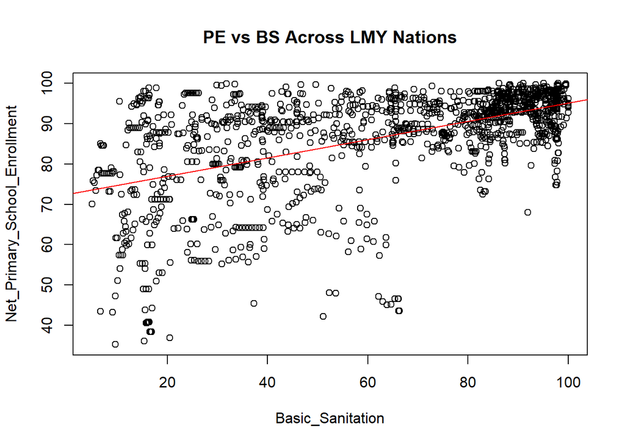

```r
#Scatterplots and Histograms of Data

plot(Net_Primary_School_Enrollment~Basic_Sanitation, data = Filtered.LMY.Data, main = "PE vs BS Across LMY Nations")
abline(Filtered.Plot.Line, col="red")
```

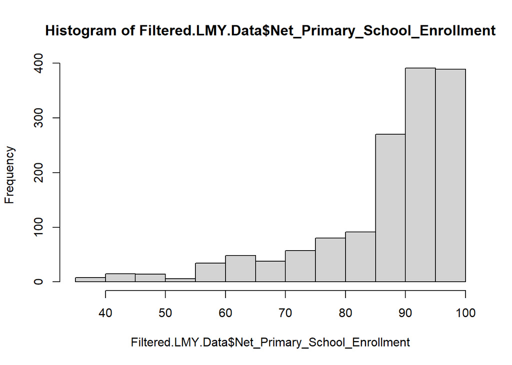

```r
hist(Filtered.LMY.Data$Net_Primary_School_Enrollment, breaks = 10)
```

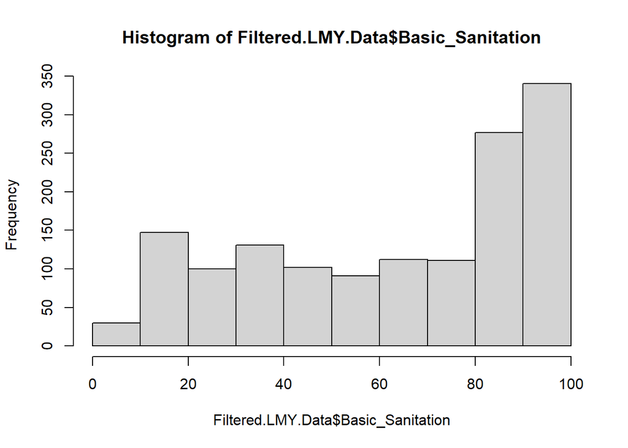

```r
hist(Filtered.LMY.Data$Basic_Sanitation, breaks = 10)
```

Looking at the scatterplot, it is clear that the data is very heavily skewed in favor of data with high basic sanitation and high primary education enrollment. This skew is clearly demonstrated by the odd line of best fit, which only intersects the dense cluster of data points in the top right corner of the graph.

A histogram of both variables shows that the data is definitely not normally distributed, meaning t-testing and ANOVA testing are not helpful here. Further, both variables demonstrate a leftward skew and the skew is much more pronounced for primary school enrollment. Because the relationship between basic sanitation and primary school enrollment appears so different at lower levels, it is feasible that filtering below the skew of Net_Primary_School_Enrollment and repeating the regression analysis would demonstrate the extent to which this relationship holds. In other words, different levels of development would demonstrate different patterns within these variables.

Three filtering options are available.The first is to filter for results below the median (90.98). The second is to filter below the mean (86.8053713). The third is to filter based on official development classifications published by the World Bank on the assumption that development level indicates different patterns. Because of the heavy skew in the data, the mean will be used to re-filter data.

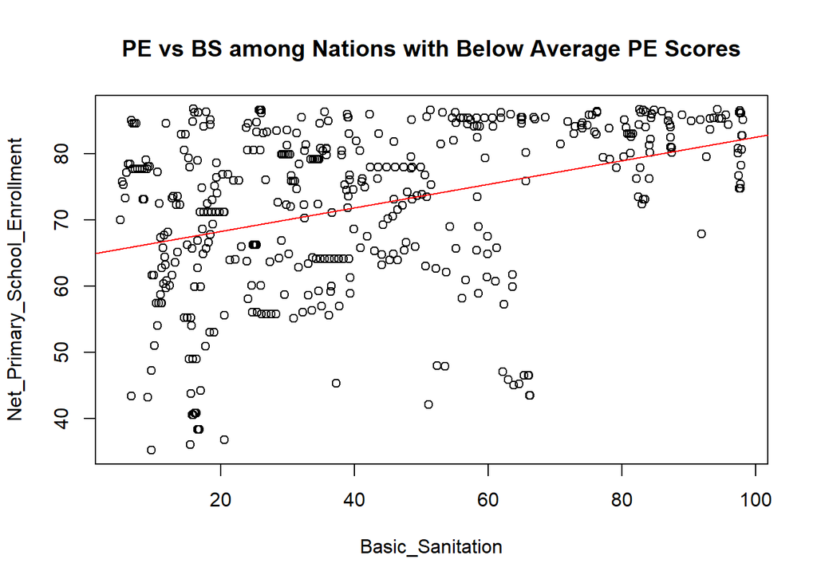

```r
#Filtering for Below Average PE Scores

Low.Primary.Enrollment<-filter(Filtered.LMY.Data, Filtered.LMY.Data$Net_Primary_School_Enrollment<mean(Filtered.LMY.Data$Net_Primary_School_Enrollment))
Low.Primary.Enrollment.Line<-lm(Net_Primary_School_Enrollment~Basic_Sanitation, data=Low.Primary.Enrollment)
plot(Net_Primary_School_Enrollment~Basic_Sanitation, data=Low.Primary.Enrollment, main = "PE vs BS among Nations with Below Average PE Scores")
abline(Low.Primary.Enrollment.Line, col="red")
```

The new scatterplot seems to show a much weaker relationship and the regression line is much less predictive of Basic_Sanitation. Next are the summary statistics of the regression.

```r
#Linear Regression of Below Average Primary School Enrollment

summary(Low.Primary.Enrollment.Line)
```

```
##
## Call:
## lm(formula = Net_Primary_School_Enrollment ~ Basic_Sanitation,
##     data = Low.Primary.Enrollment)
##
## Residuals:
##     Min      1Q  Median      3Q     Max
## -33.073  -6.918   3.064   8.451  19.210
##
## Coefficients:
##                  Estimate Std. Error t value Pr(>|t|)
## (Intercept)      64.75397    1.03036  62.846   <2e-16 ***
## Basic_Sanitation  0.17793    0.02046   8.695   <2e-16 ***
## ---
## Signif. codes:  0 '***' 0.001 '**' 0.01 '*' 0.05 '.' 0.1 ' ' 1
##
## Residual standard error: 11.75 on 460 degrees of freedom
## Multiple R-squared:  0.1411, Adjusted R-squared:  0.1393
## F-statistic:  75.6 on 1 and 460 DF,  p-value: < 2.2e-16
```

Statistically speaking, there is still a strong relation between Basic_Sanitation and Net_Primary_School_Enrollment due to the F-statistic being above 75.6 and p-value being far below .05. Interestingly, no data points are located in the bottom-right corner of the scatterplot, while many are located in the top-left corner. This suggests that improved basic sanitation scores contribute to higher primary school enrollment, while higher primary school enrollment does not contribute to higher sanitation. Plotting and performing a regression of above average PE scores will enable analyzing the clustered area further.

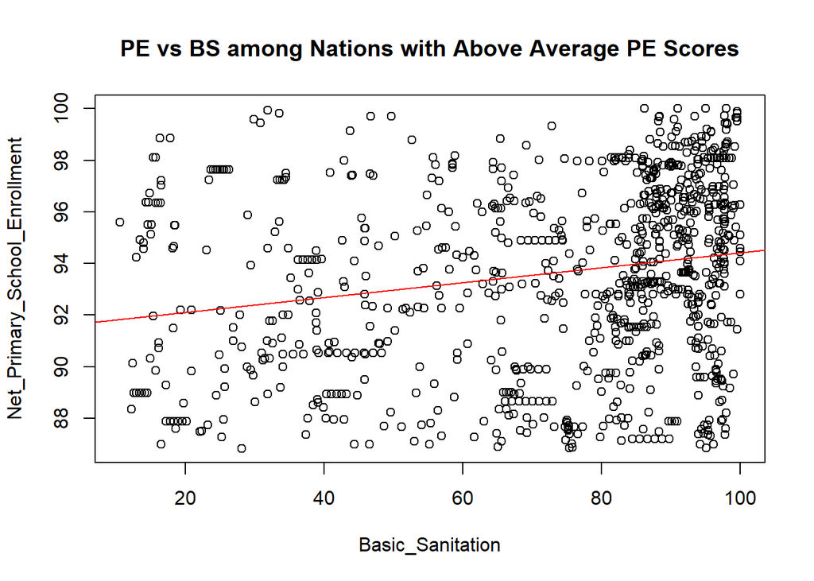

```r
High.Primary.Enrollment<-filter(Filtered.LMY.Data, Filtered.LMY.Data$Net_Primary_School_Enrollment>mean(Filtered.LMY.Data$Net_Primary_School_Enrollment))
High.Primary.Enrollment.Line<-lm(Net_Primary_School_Enrollment~Basic_Sanitation, data=High.Primary.Enrollment)
plot(Net_Primary_School_Enrollment~Basic_Sanitation, data=High.Primary.Enrollment, main = "PE vs BS among Nations with Above Average PE Scores")
abline(High.Primary.Enrollment.Line, col="red")
```

```r
summary(High.Primary.Enrollment.Line)
```

```
##
## Call:
## lm(formula = Net_Primary_School_Enrollment ~ Basic_Sanitation,
##     data = High.Primary.Enrollment)
##
## Residuals:
##     Min      1Q  Median      3Q     Max
## -7.4239 -2.4702  0.1834  2.7549  7.4905
##
## Coefficients:
##                   Estimate Std. Error t value Pr(>|t|)
## (Intercept)      91.516005   0.342031 267.566  < 2e-16 ***
## Basic_Sanitation  0.029006   0.004446   6.524  1.1e-10 ***
## ---
## Signif. codes:  0 '***' 0.001 '**' 0.01 '*' 0.05 '.' 0.1 ' ' 1
##
## Residual standard error: 3.459 on 977 degrees of freedom
## Multiple R-squared:  0.04175,    Adjusted R-squared:  0.04076
## F-statistic: 42.56 on 1 and 977 DF,  p-value: 1.097e-10
```

Recreating the scatterplot only for Net_Primary_School_Enrollment data higher than the mean shows a fair amount of variability of scores across the spectrum of Basic_Sanitation scores. This is represented by the lower F-statistic of 42.56. However, the F-statistic is still very high and this suggests that greater access to basic sanitation is related to greater primary school enrollment.

The next section will follow the same analytical method, but filtering based on Basic_Sanitation instead of Net_Primary_School_Enrollment.

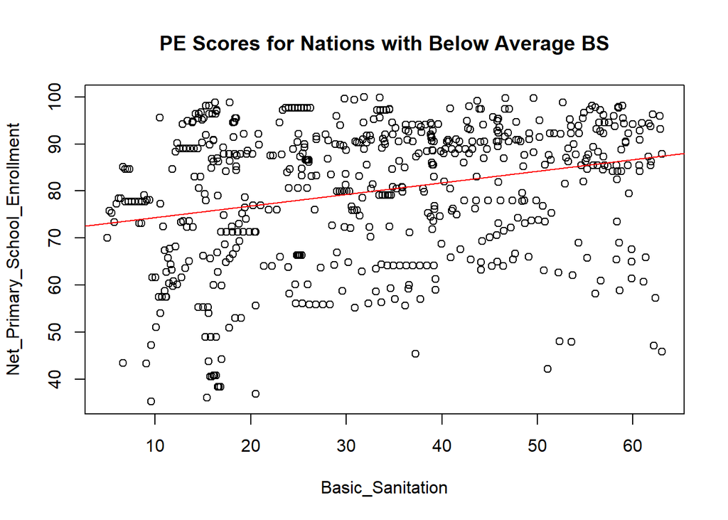

```r
Low.Basic_Sanitation<-filter(Filtered.LMY.Data, Filtered.LMY.Data$Basic_Sanitation<mean(Filtered.LMY.Data$Basic_Sanitation))
Low.BS.Line<-lm(Net_Primary_School_Enrollment~Basic_Sanitation, data=Low.Basic_Sanitation)
plot(Net_Primary_School_Enrollment~Basic_Sanitation, data=Low.Basic_Sanitation, main="PE Scores for Nations with Below Average BS")
abline(Low.BS.Line, col="red")
```

```r
summary(Low.BS.Line)
```

```
##
## Call:
## lm(formula = Net_Primary_School_Enrollment ~ Basic_Sanitation,
##     data = Low.Basic_Sanitation)
##
## Residuals:
##     Min      1Q  Median      3Q     Max
## -42.309  -9.424   3.699  10.919  22.953
##
## Coefficients:
##                  Estimate Std. Error t value Pr(>|t|)
## (Intercept)      71.90087    1.33007   54.06  < 2e-16 ***
## Basic_Sanitation  0.24595    0.03628    6.78 2.81e-11 ***
## ---
## Signif. codes:  0 '***' 0.001 '**' 0.01 '*' 0.05 '.' 0.1 ' ' 1
##
## Residual standard error: 14.21 on 619 degrees of freedom
## Multiple R-squared:  0.06913,    Adjusted R-squared:  0.06762
## F-statistic: 45.97 on 1 and 619 DF,  p-value: 2.809e-11
```

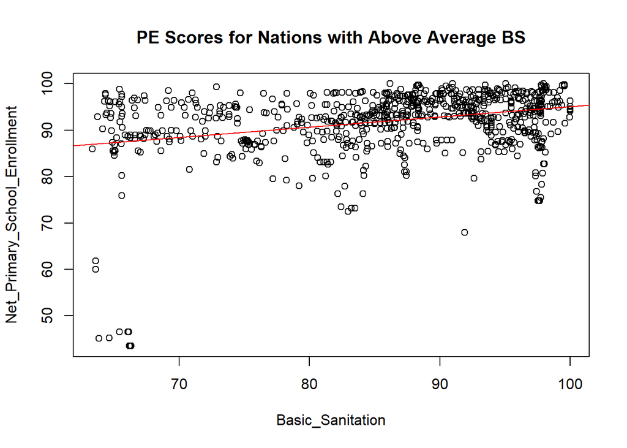

```r
High.Basic_Sanitation<-filter(Filtered.LMY.Data, Filtered.LMY.Data$Basic_Sanitation>mean(Filtered.LMY.Data$Basic_Sanitation))
High.BS.Line<-lm(Net_Primary_School_Enrollment~Basic_Sanitation, data=High.Basic_Sanitation)
plot(Net_Primary_School_Enrollment~Basic_Sanitation, data=High.Basic_Sanitation, main="PE Scores for Nations with Above Average BS")
abline(High.BS.Line, col="red")
```

```r
summary(High.BS.Line)
```

```
##
## Call:
## lm(formula = Net_Primary_School_Enrollment ~ Basic_Sanitation,
##     data = High.Basic_Sanitation)
##
## Residuals:
##     Min      1Q  Median      3Q     Max
## -44.124  -2.147   1.241   4.164  11.435
##
## Coefficients:
##                  Estimate Std. Error t value Pr(>|t|)
## (Intercept)      72.96885    2.10742  34.625   <2e-16 ***
## Basic_Sanitation  0.22071    0.02437   9.055   <2e-16 ***
## ---
## Signif. codes:  0 '***' 0.001 '**' 0.01 '*' 0.05 '.' 0.1 ' ' 1
##
## Residual standard error: 6.999 on 818 degrees of freedom
## Multiple R-squared:  0.09111,    Adjusted R-squared:   0.09
## F-statistic:    82 on 1 and 818 DF,  p-value: < 2.2e-16
```

Filtering instead based on Basic_Sanitation scores above and below the average is very illustrative. While high enrollment can occur in nations with poor basic sanitation, low enrollment scores are extremely uncommon for nations with strong basic sanitation. Their summary statistics also show a higher F-score for higher Basic_Sanitation scores. As such, using Basic_Sanitation data to predict Net_Primary_School_Enrollment is more feasible above the average Basic_Sanitation score than below it.

Before analyzing the data, it may be useful to understand which nations are above the average score and compare it to nations missing data for Net_Primary_School_Enrollment.

```r
#Calculating Average BS Scores

Yes.NA.Primary.School<-filter(simplified.LMY.Data, is.na(simplified.LMY.Data[1:1668, 3])=="TRUE")
Yes.NA.PE.No.NA.BS<-filter(Yes.NA.Primary.School, is.na(Yes.NA.Primary.School$Basic_Sanitation)==FALSE)
No.NA.Basic_Sanitation<-filter(simplified.LMY.Data, is.na(simplified.LMY.Data$Basic_Sanitation)==FALSE)
```

Thankfully, there does not appear to be a meaningful difference in average Basic_Sanitation scores for nations with and without primary school enrollment data. Their respective averages are 63.1626707 and 63.2937186. As such, sorting the data lacking primary school data for only values above the average is still realistic.

The next section will filter only for nations missing Net_Primary_School_Enrollment but with above average Basic_Sanitation scores. The regression formula will come from the High.BS.Line item noted earlier (line 157) and will be used to estimate the missing null values. The formula is: PE=72.96+.22071BS where PE is Net_Primary_School_Enrollment and BS is Basic_Sanitation.

```r
#Estimating PE Values

Above_Average_BS<-filter(Yes.NA.PE.No.NA.BS, Yes.NA.PE.No.NA.BS$Basic_Sanitation>mean(Yes.NA.PE.No.NA.BS$Basic_Sanitation))
New_PE_Estimate<-mutate(Above_Average_BS,
                        PE_Estimation=72.96+.2207*Basic_Sanitation)
kable(New_PE_Estimate)
```

| Country | Year | Net_Primary_School_Enrollment | Basic_Sanitation | PE_Estimation |
| --- | --- | --- | --- | --- |
| American Samoa | 2007 | NA | 64.84 | 87.27019 |
| American Samoa | 2008 | NA | 64.84 | 87.27019 |
| American Samoa | 2009 | NA | 63.68 | 87.01418 |
| Bosnia and Herzegovina | 2007 | NA | 95.17 | 93.96402 |
| Bosnia and Herzegovina | 2008 | NA | 95.18 | 93.96623 |
| Bosnia and Herzegovina | 2009 | NA | 95.20 | 93.97064 |
| Bosnia and Herzegovina | 2010 | NA | 95.22 | 93.97505 |
| Bosnia and Herzegovina | 2011 | NA | 95.24 | 93.97947 |
| Bosnia and Herzegovina | 2012 | NA | 95.25 | 93.98167 |
| Bosnia and Herzegovina | 2013 | NA | 95.27 | 93.98609 |
| Bosnia and Herzegovina | 2014 | NA | 95.29 | 93.99050 |
| Bosnia and Herzegovina | 2015 | NA | 95.31 | 93.99492 |
| Bosnia and Herzegovina | 2016 | NA | 95.34 | 94.00154 |
| Bosnia and Herzegovina | 2017 | NA | 95.36 | 94.00595 |
| Bosnia and Herzegovina | 2018 | NA | 95.36 | 94.00595 |
| China | 2008 | NA | 70.12 | 88.43548 |
| China | 2009 | NA | 71.86 | 88.81950 |
| China | 2010 | NA | 73.55 | 89.19249 |
| China | 2011 | NA | 75.19 | 89.55443 |
| China | 2012 | NA | 76.80 | 89.90976 |
| China | 2013 | NA | 78.46 | 90.27612 |
| China | 2014 | NA | 80.08 | 90.63366 |
| China | 2015 | NA | 81.68 | 90.98678 |
| China | 2016 | NA | 83.24 | 91.33107 |
| China | 2017 | NA | 84.76 | 91.66653 |
| China | 2018 | NA | 84.76 | 91.66653 |
| Costa Rica | 2007 | NA | 94.85 | 93.89339 |
| Costa Rica | 2008 | NA | 95.05 | 93.93753 |
| Costa Rica | 2009 | NA | 95.40 | 94.01478 |
| Costa Rica | 2010 | NA | 95.74 | 94.08982 |

[output cut: 73 more lines]

```r
#Tokelau Data

filter(simplified.LMY.Data, simplified.LMY.Data$Country=="Tokelau")
```

```
##    Country Year Net_Primary_School_Enrollment Basic_Sanitation
## 1  Tokelau 2007                            NA            81.45
## 2  Tokelau 2008                            NA            83.03
## 3  Tokelau 2009                            NA            84.61
## 4  Tokelau 2010                        100.00            86.19
## 5  Tokelau 2011                            NA            87.78
## 6  Tokelau 2012                            NA            89.37
## 7  Tokelau 2013                        100.00            90.97
## 8  Tokelau 2014                            NA            92.57
## 9  Tokelau 2015                            NA            94.17
## 10 Tokelau 2016                         91.66            95.75
## 11 Tokelau 2017                            NA            96.66
## 12 Tokelau 2018                            NA               NA
```

```r
#Rwanda Data

filter(simplified.LMY.Data, simplified.LMY.Data$Country=="Rwanda")
```

```
##    Country Year Net_Primary_School_Enrollment Basic_Sanitation
## 1   Rwanda 2007                         85.50            54.60
## 2   Rwanda 2008                         85.50            55.82
## 3   Rwanda 2009                         85.50            57.04
## 4   Rwanda 2010                         85.50            58.26
## 5   Rwanda 2011                         85.50            59.47
## 6   Rwanda 2012                         85.50            60.67
## 7   Rwanda 2013                         85.50            61.87
## 8   Rwanda 2014                            NA            63.06
## 9   Rwanda 2015                            NA            64.24
## 10  Rwanda 2016                         98.84            65.41
## 11  Rwanda 2017                         96.93            66.57
## 12  Rwanda 2018                         94.79            66.57
```

In the case of Rwanda, only years 2014 and 2015 are missing PE data. The regression’s estimates for the year 2015 is 87.14. This is a reasonable estimate given the steadily increasing BS scores and the fact PE scores increased from 85.50 in 2013 to 98.84 in 2016.

```r
#Iraq Data

filter(simplified.LMY.Data, simplified.LMY.Data$Country=="Iraq")
```

```
##    Country Year Net_Primary_School_Enrollment Basic_Sanitation
## 1     Iraq 2007                          92.8            77.61
## 2     Iraq 2008                          92.8            79.21
## 3     Iraq 2009                          92.8            80.82
## 4     Iraq 2010                          92.8            82.44
## 5     Iraq 2011                          92.8            84.09
## 6     Iraq 2012                          92.8            85.74
## 7     Iraq 2013                          92.8            87.40
## 8     Iraq 2014                          92.8            89.07
## 9     Iraq 2015                          92.8            90.74
## 10    Iraq 2016                          92.8            92.43
## 11    Iraq 2017                          92.8            94.12
## 12    Iraq 2018                            NA            94.12
```

In the case of Iraq, only PE data for 2018 is missing. The regression’s estimate for the missing data is 93.73.

How useful are these estimates? Note that the average PE score across LMY nations not missing PE data is 86.7641898. For nations like Rwanda, this may be close enough. However, none of the nations’ PE estimates fall below this average and some, like Iraq and Tokelau, are considerably higher and data from other years suggests this estimate is more accurate.

For most of these data, using the average PE value as a substitute for null values instead of a regression estimate would likely underestimate educational enrollment at the higher end of the distribution. This is typical when substituting null values with an average. However, the analysis shows how doing so can be misleading when used in a human rights or development context. The wide variety of different kinds of development which exist and the different statistical patterns which are exhibited at different places in the development spectrum mean that estimation using the average of an immensely complex gamut of international trends is unrealistic. Doing so may even be harmful given the human rights and developmental implications. Moreover, having nation-specific estimates of economic development patterns is more helpful because a considerable amount of human rights and development analysis is nation-specific or regional instead of global.

Is this strategy feasible for other data and socioeconomic strata? Next, this analysis will repeat the filtering and regression process for the high-income nation (HiY) dataset. The “Net Secondary School Enrolment” and “People with at least safely managed sanitation” data will be used to analyze high-income nations, as these data are specific to high-income nations and are comparable to the data used in the LMY analysis. Instead of excluding results based on average, data above the average for sanitation are colored light blue and a regression of all nations in the dataframe is performed.

```r
#Redaction of HiY Dataset

ESR_HIY<-read.csv("ESR_HIY_Data.csv")
colnames(ESR_HIY)
```

```
##  [1] "Country_Code"
##  [2] "Country"
##  [3] "High_Income_Country"
##  [4] "Year"
##  [5] "GlobalBest_HiY_Quality_Of_Life_Score"
##  [6] "GlobalBest_HiY_Right_to_Education_Score"
##  [7] "GlobalBest_HiY_Right_to_Food_Score"
##  [8] "GlobalBest_HiY_Right_to_Health_Score"
##  [9] "GlobalBest_HiY_Right_to_Housing_Score"
## [10] "GlobalBest_HiY_Right_to_Work_Score"
## [11] "Most_Recent_Observation_Net_Secondary_School_Enrollment"
## [12] "Year_of_Most_Recent_Observation_on_Net_Secondary_School_Enrollment"
## [13] "GDP_per_capita_.2017_PPP.._for_Most_Recent_Observation_Net_Secondary_School_Enrollment"
## [14] "Applied_GB_Penalty_for_Net_Secondary_School_Enrollment"
## [15] "GlobalBest_Score_for_Net_Secondary_School_Enrollment"
```

[output cut: 61 more lines]

```r
#relevant column indexes are 2, 3, 4, 11, 52
high.income.countries<-filter(ESR_HIY, ESR_HIY$High_Income_Country==1)
Country2<-high.income.countries$Country
Year2<-high.income.countries$Year
Net_Secondary_School_Enrollment<-high.income.countries$Most_Recent_Observation_Net_Secondary_School_Enrollment
Safely_Managed_Sanitation<-high.income.countries$Most_Recent_Observation_._Safe_Sanitation
simplified.HIY.Data<-data.frame(Country2, Year2, Net_Secondary_School_Enrollment, Safely_Managed_Sanitation)
#simplified data set has been made.

Safely_Managed_Sanitation.NoNA<-filter(simplified.HIY.Data, simplified.HIY.Data$Safely_Managed_Sanitation!="NA")
High_Income_HIY_No_NA<-filter(Safely_Managed_Sanitation.NoNA, Safely_Managed_Sanitation.NoNA$Net_Secondary_School_Enrollment!="NA")
#NA values have been removed.
```

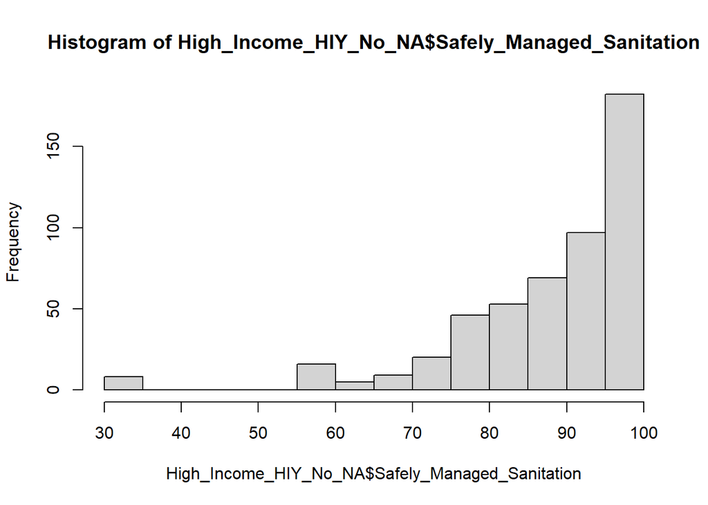

```r
#Histograms and Scatterplots of HiY Data

hist(High_Income_HIY_No_NA$Safely_Managed_Sanitation)
```

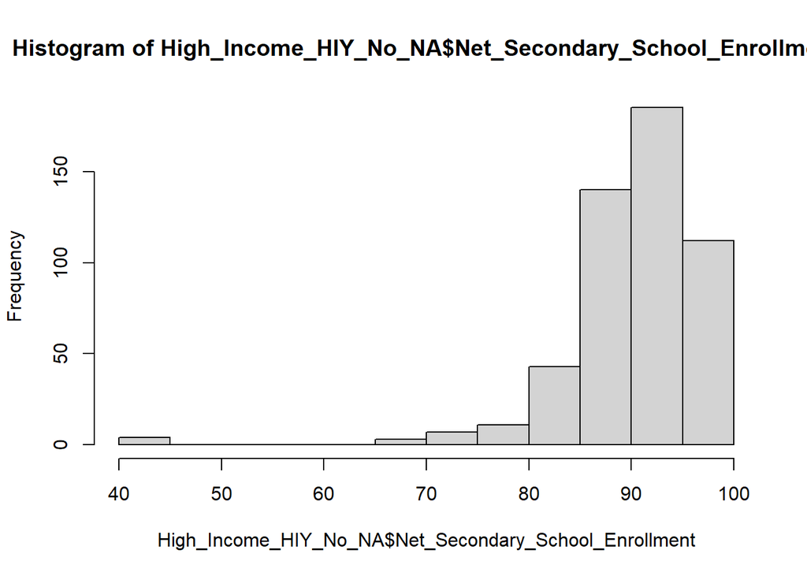

```r
hist(High_Income_HIY_No_NA$Net_Secondary_School_Enrollment)
```

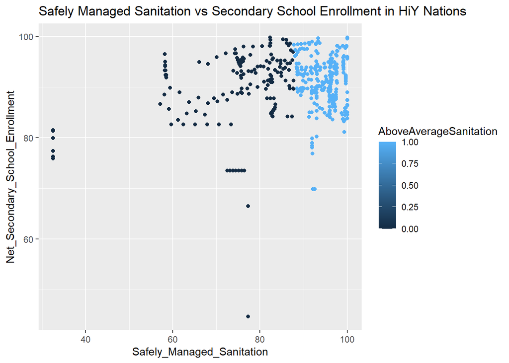

```r
Above_Average_Sanitation<-mutate(High_Income_HIY_No_NA, AboveAverageSanitation = ifelse(High_Income_HIY_No_NA$Safely_Managed_Sanitation>mean(High_Income_HIY_No_NA$Safely_Managed_Sanitation), 1, 0)) #creation of a dummy variable.

Above_Average_Sanitation_plot<-ggplot(Above_Average_Sanitation, aes(x=Safely_Managed_Sanitation, y=Net_Secondary_School_Enrollment, col=AboveAverageSanitation))
Above_Average_Sanitation_plot+geom_point()+labs(title="Safely Managed Sanitation vs Secondary School Enrollment in HiY Nations")
```

```r
summary(lm(Net_Secondary_School_Enrollment~Safely_Managed_Sanitation, data=High_Income_HIY_No_NA)) #linear regression of Safely_Managed_Sanitation and Net_Secondary_School_Enrollment
```

```
##
## Call:
## lm(formula = Net_Secondary_School_Enrollment ~ Safely_Managed_Sanitation,
##     data = High_Income_HIY_No_NA)
##
## Residuals:
##     Min      1Q  Median      3Q     Max
## -44.510  -3.075   1.018   4.073   9.935
##
## Coefficients:
##                           Estimate Std. Error t value Pr(>|t|)
## (Intercept)               80.25196    2.12170  37.824  < 2e-16 ***
## Safely_Managed_Sanitation  0.11690    0.02395   4.881 1.42e-06 ***
## ---
## Signif. codes:  0 '***' 0.001 '**' 0.01 '*' 0.05 '.' 0.1 ' ' 1
##
## Residual standard error: 6.655 on 503 degrees of freedom
## Multiple R-squared:  0.04523,    Adjusted R-squared:  0.04333
## F-statistic: 23.83 on 1 and 503 DF,  p-value: 1.418e-06
```

After repeating the data filtering, plotting, and regression analysis steps used in the LMY data set, some important commonalities and differences can be observed. First is that the histograms are similarly skewed to the left. Second is the clustering in the top-right corner of the scatterplot, indicating a relationship between high sanitation and high educational enrollment. However, the corresponding F-score is much lower at 23.83 and some significant outliers can be seen. While the F-score and p-value both suggest a statistically significant relationship between the Safely_Managed_Sanitation and Net_Secondary_School_Enrollment data, this relationship only demonstrates some of the patterns of the previous analysis.

What does this mean? The differences between the LMY and HiY analyses may be partly due to the differences in data used. While similar, there may be numerous statistically-meaningful differences between primary and secondary school enrollment which lead to different data trends. However, it is also apparent that different developmental patterns occur at different stages of development. Primary school enrollment may be challenging to predict at low levels of basic sanitation development but easier to develop at higher ones. Sanitation as a predictor variable may become less useful once again at high income levels due to nations achieving more complicated bureaucracy and institutions which may also contribute to developmental patterns. It is also possible that, since developed nations generally have strong sanitation and rarely fall below 60 in safe sanitation management (visible in the scatterplot), sanitation is not a meaningful predictor and another variable might better predict secondary school enrollment.

Conclusion:

The desire for quick and easy assessment strategies is common in global development and human rights. Unfortunately, gaps in data availability make assessing a nation’s developmental standing difficult in many cases.As this analysis has shown, assigning average values to missing data can misrepresent a nation’s current developmental standing. This is particularly unhelpful for local developers and policymakers who work with specific nations and not the entire globe. There is an opportunity to use regression analysis to develop linear models capable of approximating some of these null values. However, doing so requires a careful understanding of the data and thorough data analysis. Further, regression methods which are effective among certain nations or with specific variables may not be effective in other contexts. As development work continues, developmental organizations and peacebuilders will need to remember that there are no panacea in this field.

Sources (all available at humanrightsmeasurement.org):

Human Rights Measurement Initiative (HRMI). 2021. “HRMI Human Rights Dataset.” https://humanrightsmeasurement.org/. Version 2020.6.23.

Susan Randolph, John Stewart, Sakiko Fukuda-Parr, and Terra Lawson-Remer. 2021 “HRMI Economic and Social Rights Metrics 2020 Technical Note.” 23 June 2021. https://humanrightsmeasurement.org/methodology-handbook/

Sakiko Fukuda-Parr, Terra Lawson-Remer and Susan Randolph. 2015. Fulfilling Social and Economic Rights. Oxford: Oxford University Press.

Economic & Social Rights Empowerment Initiative. 2020. https://serfindex.uconn.edu/.